# Priorización Espacial para Colombia: Activos Naturales Críticos y Cambio en Servicios Ecosistémicos

Global Science WWF

Jerónimo Rodríguez Escobar

Rebecca Chaplin-Kramer

Richard P. Sharp

1 de septiembre, 2026

## La Alianza Natural Capital y WWF Global Science

- La Alianza Natural Capital nació hace ~20 años en Stanford y reúne a:
  - **WWF, Stanford, University of Minnesota, The Nature Conservancy, la Academia China de Ciencias y el Stockholm Resilience Centre**.
- Ha producido herramientas de código abierto para integrar el valor de la naturaleza en la toma de decisiones — p. ej. **InVEST**, RIOS, OPAL, ROOT y MESH.
- Global Science:
  - **CONVEI** — consorcio WWF/NASA/NOAA/USGS que valora datos de observación de la Tierra para la toma de decisiones, PI **Rebecca Chaplin-Kramer** — Global Biodiversity Lead Scientist.
  - **NatCap TEEMs** (U. of Minnesota) — modelos que integran economía, comercio y servicios ecosistémicos; lidera el proyecto de metodología para estimar el **GEP Global** (Producto Ecosistémico Bruto — un índice modelado sobre el PIB, para el valor de los servicios ecosistémicos).
  - **Conservation Navigator** — datos y análisis curados para apoyar la toma de decisiones de conservación.
- Marco general: **Roadmap 2030**.

## Sobre mi

- **Economista y PhD en Geografía y Estudios Urbanos** (Temple University, 2025), con foco en *land systems science*: un campo que integra monitoreo satelital de cambio de uso y cobertura del suelo (observación de la Tierra, SIG, machine learning) con teorías de rango medio, para explicar no solo qué cambia en el paisaje, sino cómo y para quién.
  - Tesis doctoral: uso y control de la tierra en la formación de una frontera de commodities — expansión del agronegocio en las sabanas orientales de Colombia durante el siglo XXI.
- Formación interdisciplinaria: BSc Economía (Universidad Nacional de Colombia), MSc Economía Agrícola (Humboldt Universität zu Berlin).
- Experiencia en Colombia: Instituto Alexander von Humboldt — gestión territorial de biodiversidad (2012–2016); Federación Nacional de Cafeteros; CENIPALMA.
- Monitoreo de biodiversidad y sensores remotos: NASA Earth Observations, Red de Observación de Biodiversidad de Colombia.
- Actualmente: postdoc en Ciencia Global de WWF/NatCap, trabajando activamente en el artículo científico que sustenta este análisis (hotspots globales de cambio en servicios ecosistémicos, 1992–2020).

## Enfoque global, aplicable a múltiples escalas

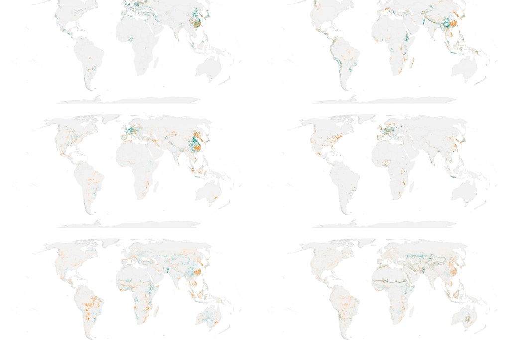

Analizamos dinámicas de servicios ecosistémicos a nivel mundial, identificando:

- **Activos críticos** (oportunidad)
- **Procesos de cambio** (declive/riesgo)
- **Detecta y analiza cambio**: convierte datos biofísicos en una señal clara: qué está cambiando, dónde y con qué severidad.
- **Métricas estandarizada**: hotspots, activos críticos, superposición de riesgo.
- **Se adapta a múltiples unidades espaciales**: país, región, cuenca, bioma.

Todo esto corre sobre **InVEST** (Integrated Valuation of Ecosystem Services and Tradeoffs) — el conjunto de modelos biofísicos de código abierto de la Alianza Natural Capital que traduce datos de suelo, clima y cobertura en servicios ecosistémicos cuantificados.

[figure not shown]

## Activos críticos, servicio por servicio

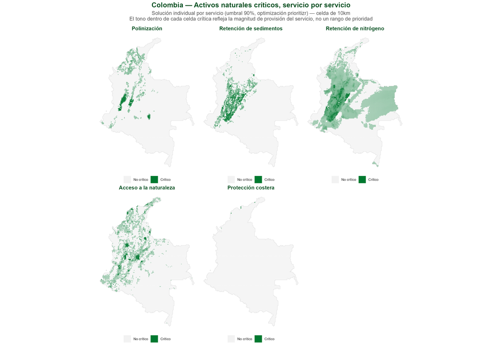

## Oportunidad: activos naturales críticos

2,93× intensidad relativa: % de activos críticos vs. % de tierra elegible global

- **Activo natural crítico** = área requerida para sostener el **90%+** de las contribuciones de la naturaleza a las personas (Chaplin-Kramer et al. 2022, *Nature Ecology & Evolution*).

| Servicio | Qué representa como activo |
| --- | --- |
| Polinización | Hábitat que sostiene polinizadores |
| Retención de sedimentos | Hábitat que retiene sedimento antes de erosionarse |
| Retención de nitrógeno | Hábitat que retiene nutrientes antes de exportarse |
| Acceso a la naturaleza | Hábitat natural accesible para la población |
| Protección costera | Hábitat que reduce el riesgo costero |

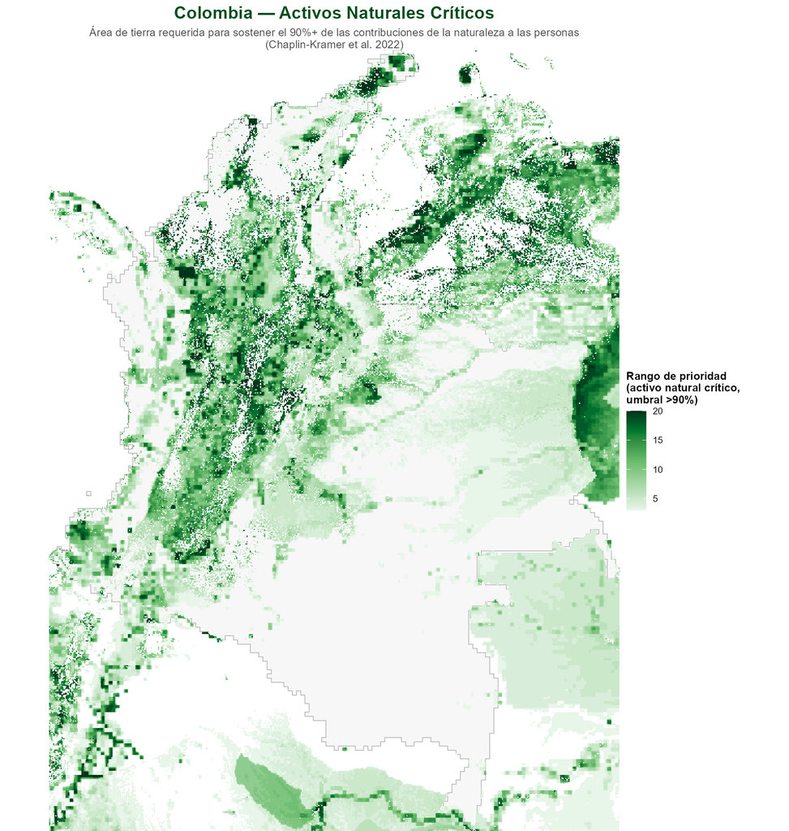

## Ahora, el cambio en los NCP

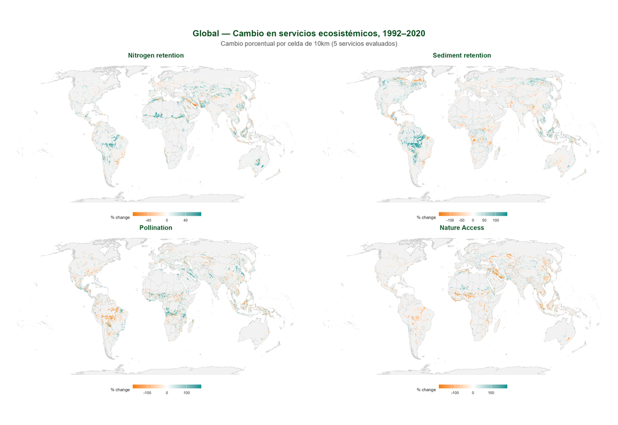

## Aplicado a Colombia

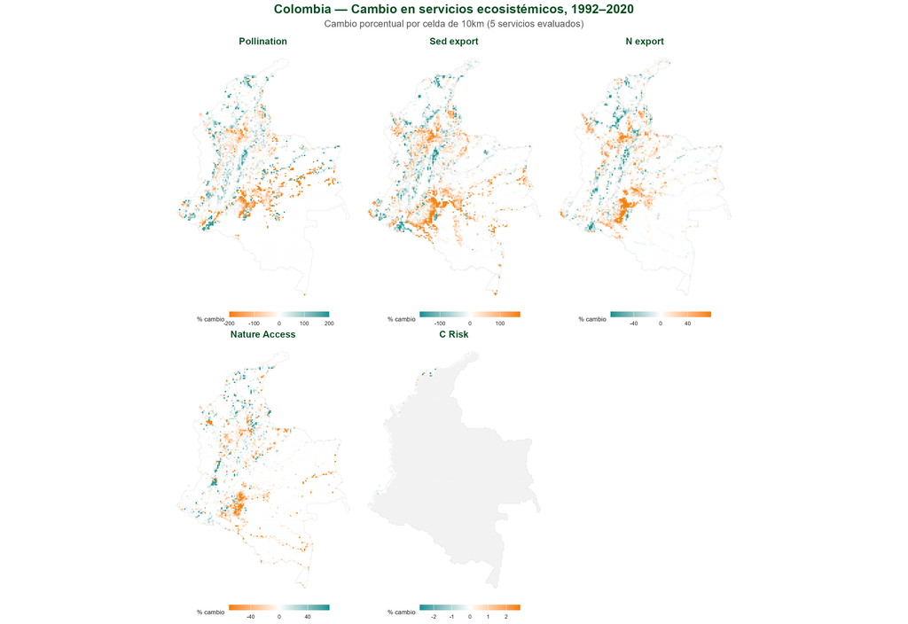

## Colombia concentra hotspots de cambio

1,60% Polinización — vs. 0,87% esperado

1,32% Exportación de sedimentos — vs. 0,87% esperado

- **Hotspot de cambio** = celda donde un servicio se deterioró con mayor severidad entre 1992 y 2020 (percentil 5% más severo) — *no* una celda de mayor provisión.
- Concentración más fuerte en **Meta, Caquetá y Antioquia** — casi empatados, muy por encima de cualquier otro departamento.

| Servicio | Qué mide |
| --- | --- |
| Polinización | Provisión de polinización por hábitat natural |
| Exportación de sedimentos | Sedimento exportado desde la cuenca (erosión) |
| Exportación de nitrógeno | Nitrógeno exportado desde la cuenca |
| Acceso a la naturaleza | Población con acceso cercano a hábitat natural |
| Riesgo costero | Nivel de riesgo costero (protección reducida) |

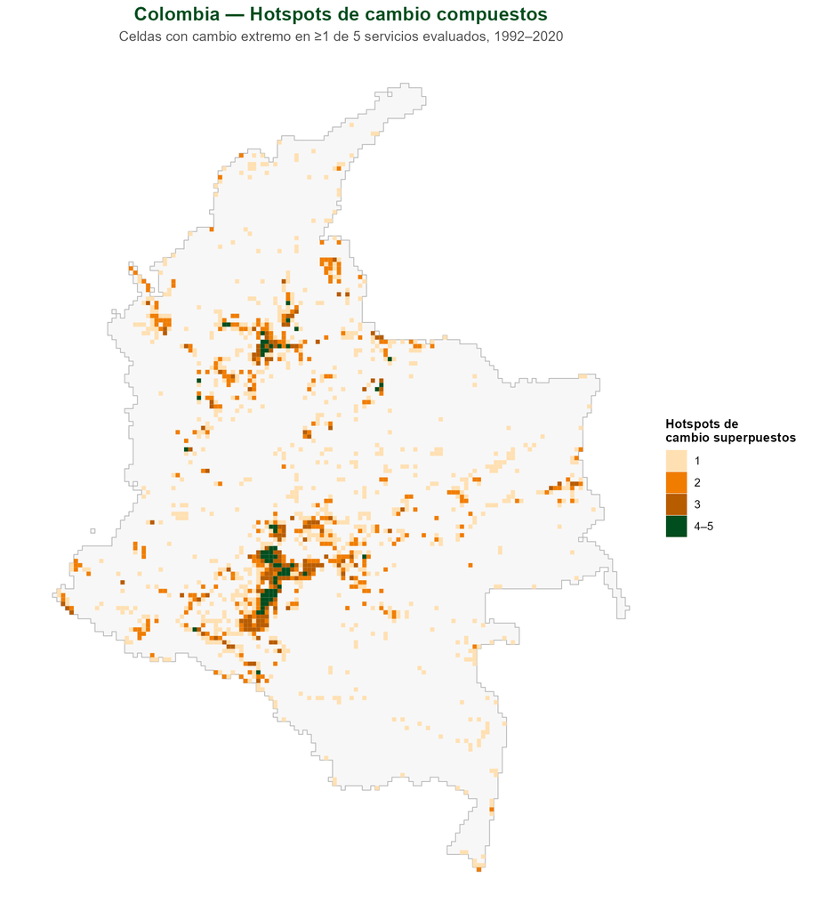

## Priorización: Donde coinciden valor y cambio

57,9% de los hotspots de cambio de Colombia caen dentro de un activo natural crítico

- Activos críticos = lugares de **mayor valor**. Hotspots de cambio = lugares de **cambio más severo**.
- De las **1.423** celdas que son hotspot de cambio en Colombia (12,5% del país), **824** también son un activo crítico.
- Aplica a proyectos viales, desarrollo agrícola, forestal, minero y energético.

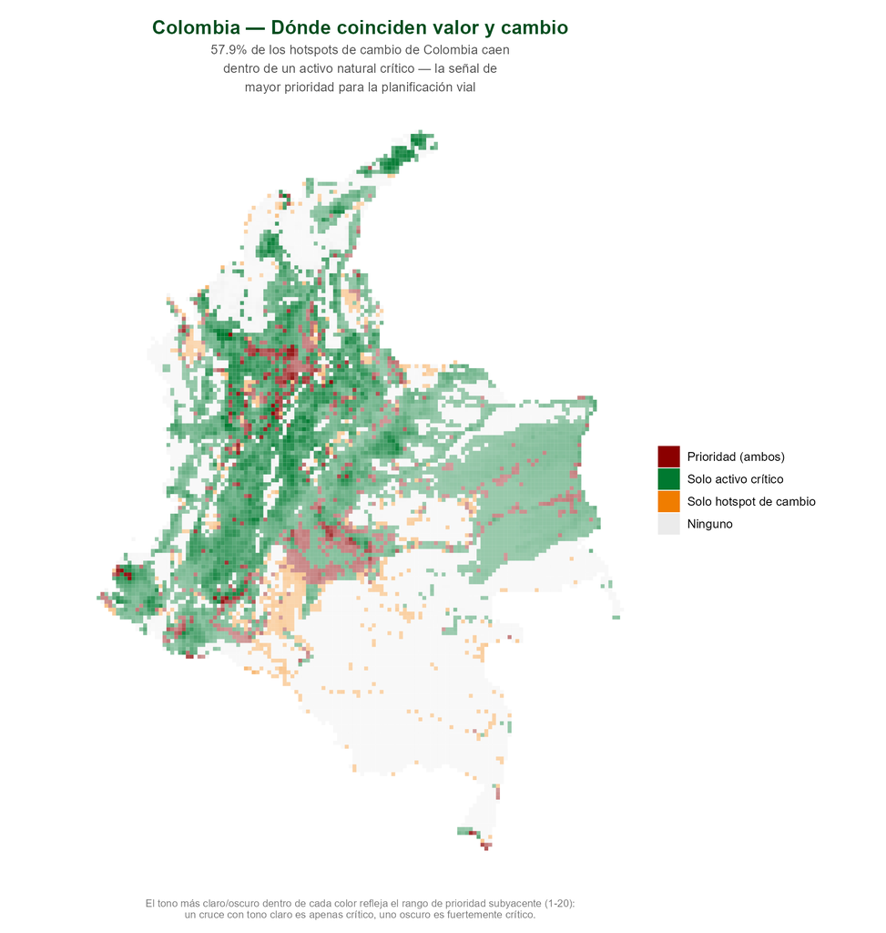

## ¿Dónde se concentra el cambio?

1,27× Bosque húmedo tropical — Exportación de sedimentos

1,13× Manglares — Exportación de sedimentos

1,33× Sabanas/Llanos — Polinización

- **En Colombia**, ¿qué bioma concentra hotspots de cambio desproporcionadamente?
- **Exportación de sedimentos** se concentra en bosque húmedo tropical y manglares — erosión/sedimentación en cuencas boscosas y zonas costeras.
- **Polinización** concentra en sabanas/Llanos — presión sobre paisajes agrícolas y de pastizal en la Orinoquía.

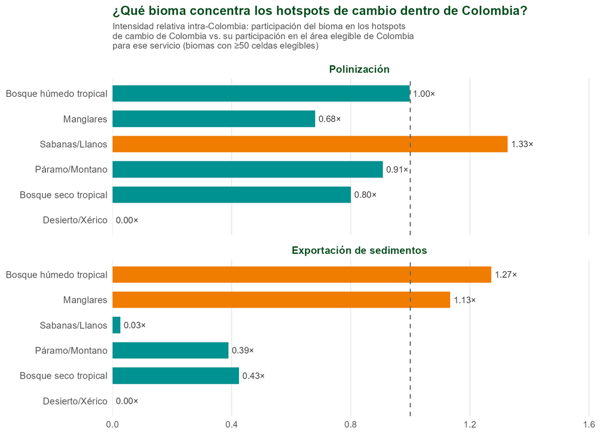

## Quién: los hotspots de cambio afectan a 3 de cada 4 colombianos

75,8% de la población colombiana expuesta a un hotspot de cambio

38,1M personas expuestas

35,5% expuesta al nivel más intenso (4-5 servicios simultáneos)

17,9M personas en ese nivel

- El área de influencia de los hotspots de cambio. Buffers estandarizados: **50km río abajo** o **1 hora de tiempo de viaje**.

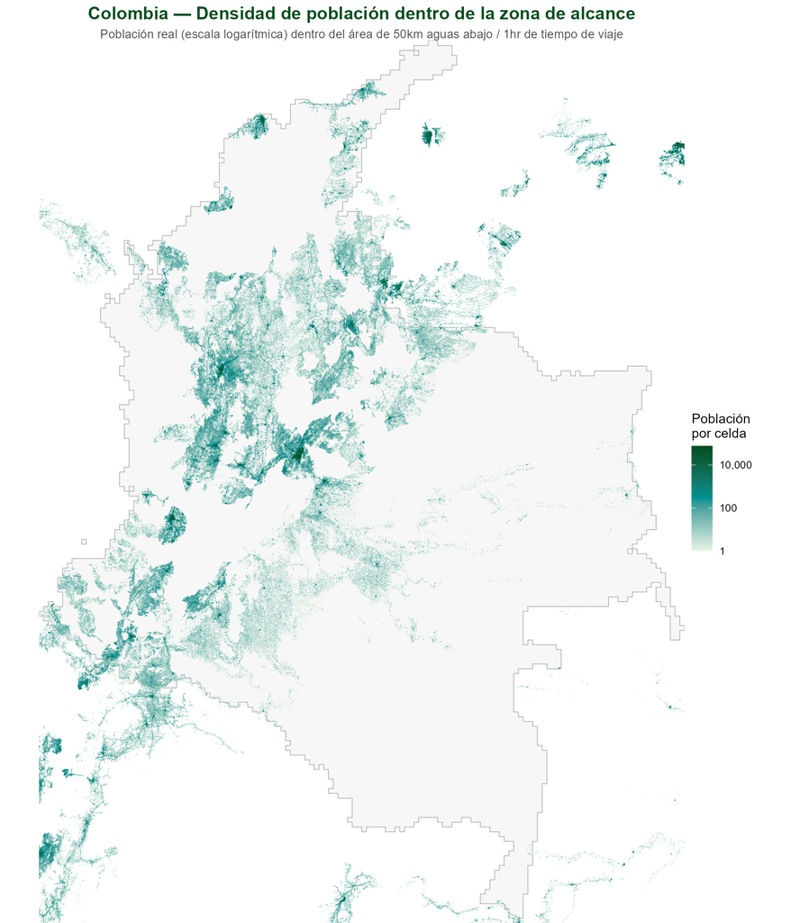

## Caso específico: infraestructura vial

1,32% de Colombia en hotspots de exportación de sedimentos — vs. 0,87% esperado por azar

- **Exportación de sedimentos** es uno de los servicios con mayor concentración de hotspots en Colombia — directamente ligada a erosión y escorrentía inducidas por construcción vial y cambios de coberturas.
- **Oportunidad**: aplicar la metodologia para apoyar la evaluación de los impactos de corredores viales propuestos en términos de servicios ecosistémicos.
- Articualción con **LIVV**: una señal de riesgo estandarizada y repetible para la selección de corredores.

## Propuesta

No es solo repetir este análisis para Colombia — es fortalecer un vínculo directo con Global Science y aportar a la capacidad instalada en WWF Colombia:

- **Profundizar el corte Colombia**: ej. Llanos/Orinoquía, transición amazónica, páramos — misma metodología.
- **Sostener reportería continua**: el mismo pipeline alimentando el seguimiento de la hoja de ruta de conservación liderada localmente de WWF Colombia — no depende de una sola persona.
- **Transferir el know-how, no solo el resultado**: pipeline de código abierto, reproducible en un IDE con flujos de trabajo asistidos por IA (agentic) — la meta es que el propio equipo en WWF Colombia pueda operarlo y expandirlo. Repositorio: github.com/springinnovate/global_NCP

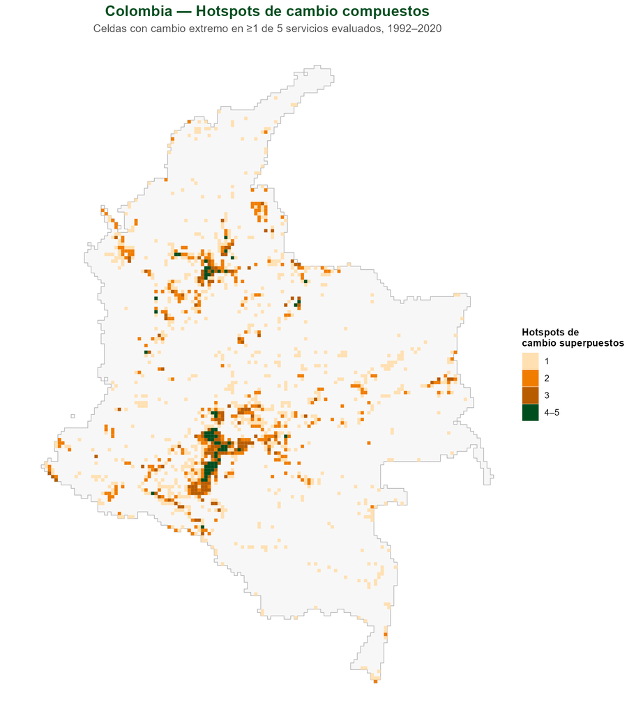